# Interaction Scoring Null Calibration & Real vs. Null Comparison

EYW

2026-09-06

```r
library(tidyverse)
library(data.table)
library(scales)
```

```r
library(patchwork)
knitr::opts_chunk$set(echo = TRUE)

source("../../functions/r_custom/plotting_fxns.R")
theme_set(theme_Publication())

filter_cutoff_single <- 0.1
filter_cutoff_interaction <- 0.1

null_dir <- "/data1/rudenska/EYW/git_projects/SIG13/analysis_outs/glmGamPoi/glmGamPoi_null"
real_interaction_dir <- "/data1/rudenska/EYW/git_projects/SIG13/analysis_outs/glmGamPoi/glmGamPoi_interaction"
```

# Goal

To assess calibration of our Gamma-Poisson GLM that modles single nad interaction effects, we calculate an empirical null-benchmark. As our screen includes 9 distinct barcoded non-targeting linker VLPs, we will treat these linker VLPs as stand ins for ligand1/ligand2 identities and run them through an *identical* GLM pipeline (same design formula, same covariates, same `filter_cutoff`, same contrasts). Substituting these linker VLPs for real ligands and testing them against each other gives a sample of test statistics drawn from a true null. This report assess the empiric null p-value distribution and compares it to the real data.

# Import

```r
nullInteraction <- fread(
  file.path(null_dir, paste0("glmGamPoi_interaction_null_lfc_", filter_cutoff_interaction, "filter.csv")),
  select = c("pval", "adj_pval", "lfc", "interaction")
) %>%
  as_tibble() %>%
  mutate(contrast = "ligand1:ligand2")

nullSingles <- fread(
  file.path(null_dir, paste0("glmGamPoi_interaction_null_singles_lfc_", filter_cutoff_interaction, "filter.csv")),
  select = c("pval", "adj_pval", "lfc")
) %>%
  as_tibble() %>%
  mutate(contrast = "ligand")

comboCoverage <- read_csv(file.path(null_dir, paste0("interaction_null_combo_coverage_", filter_cutoff_interaction, "filter.csv")))
realInteraction <- fread(
  file.path(real_interaction_dir, paste0("glmGamPoi_interaction_lfc_", filter_cutoff_interaction, "filter.csv")),
  select = c("pval", "adj_pval", "lfc", "interaction")
) %>%
  as_tibble() %>%
  mutate(contrast = "ligand1:ligand2")

realSingles <- fread(
  file.path(real_interaction_dir, paste0("glmGamPoi_singles_lfc_", filter_cutoff_interaction, "filter.csv")),
  select = c("pval", "adj_pval", "lfc")
) %>%
  as_tibble() %>%
  mutate(contrast = "ligand")
```

# Pool p-values across contrasts

```r
nullPvals <- bind_rows(
  nullInteraction %>% select(contrast, pvalue = pval, adj_pval),
  nullSingles %>% select(contrast, pvalue = pval, adj_pval)
) %>%
  filter(!is.na(pvalue))

nullPvals %>% count(contrast)
```

```
## # A tibble: 2 × 2
##   contrast             n
##   <chr>            <int>
## 1 ligand          222124
## 2 ligand1:ligand2 111062
```

```r
allPvals <- bind_rows(
  bind_rows(realInteraction, realSingles) %>% mutate(source = "real"),
  bind_rows(nullInteraction, nullSingles) %>% mutate(source = "null")
) %>%
  rename(pvalue = pval) %>%
  filter(!is.na(pvalue))

allPvals %>% count(source, contrast)
```

```
## # A tibble: 4 × 3
##   source contrast              n
##   <chr>  <chr>             <int>
## 1 null   ligand           222124
## 2 null   ligand1:ligand2  111062
## 3 real   ligand          9435942
## 4 real   ligand1:ligand2 4717971
```

# P-value distribution

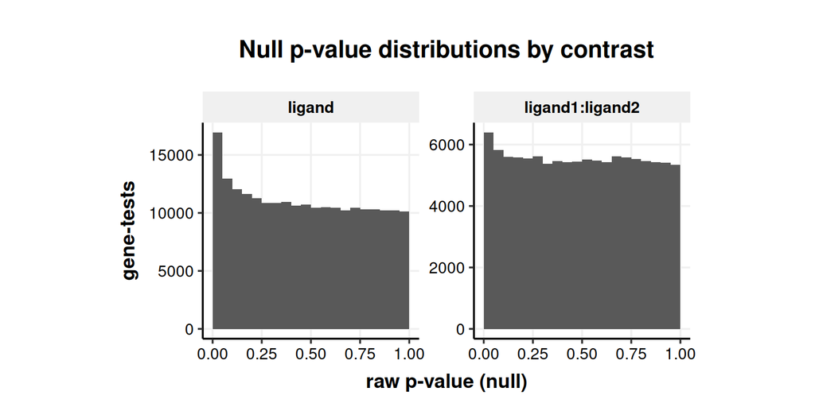

```r
ggplot(nullPvals, aes(x = pvalue)) +
  geom_histogram(breaks = seq(0, 1, by = 0.05), boundary = 0) +
  facet_wrap(~contrast, scales = "free_y") +
  labs(x = "raw p-value (null)", y = "gene-tests", title = "Null p-value distributions by contrast") +
  theme(aspect.ratio = 1)
```

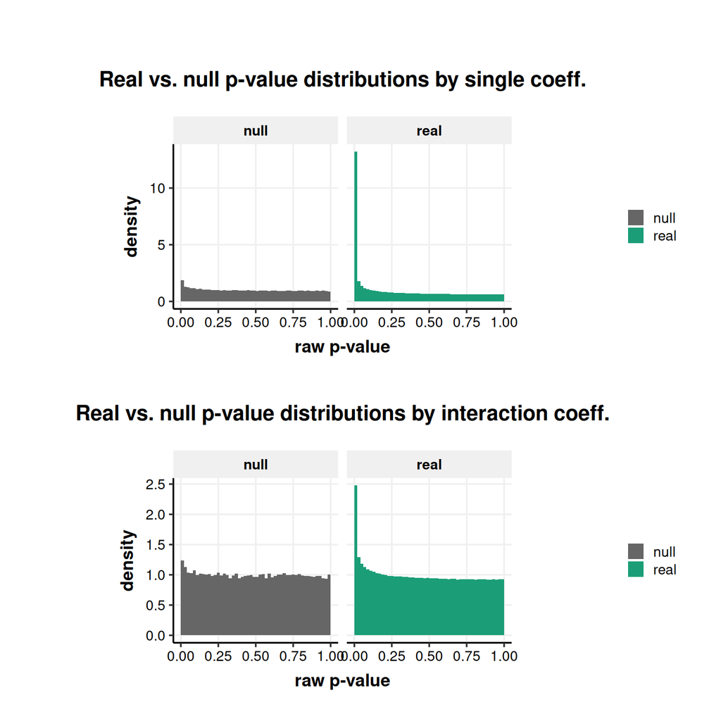

```r
ggsave("../../analysis_outs/plots/interaction_scoring_null/glm_pval_histogram_null.pdf")
p1 <- allPvals %>%
  filter(contrast == "ligand") %>%
  ggplot(aes(x = pvalue, y = after_stat(density), fill = source)) +
  geom_histogram(breaks = seq(0, 1, by = 0.02), boundary = 0, position = "identity") +
  scale_fill_manual(values = c("#666666FF", "#1B9E77FF")) +
  facet_wrap(~source) +
  labs(x = "raw p-value", y = "density", fill = NULL,
       title = "Real vs. null p-value distributions by single coeff.") +
  theme(aspect.ratio = 1)

p2 <- allPvals %>%
  filter(contrast == "ligand1:ligand2") %>%
  ggplot(aes(x = pvalue, y = after_stat(density), fill = source)) +
  geom_histogram(breaks = seq(0, 1, by = 0.02), boundary = 0, position = "identity") +
  scale_fill_manual(values = c("#666666FF", "#1B9E77FF")) +
  facet_wrap(~source) +
  labs(x = "raw p-value", y = "density", fill = NULL,
       title = "Real vs. null p-value distributions by interaction coeff.") +
  theme(aspect.ratio = 1)

p1/p2
```

```r
ggsave("../../analysis_outs/plots/interaction_scoring_null/glm_pval_histogram_real_vs_null.pdf")
```

# QQ plots

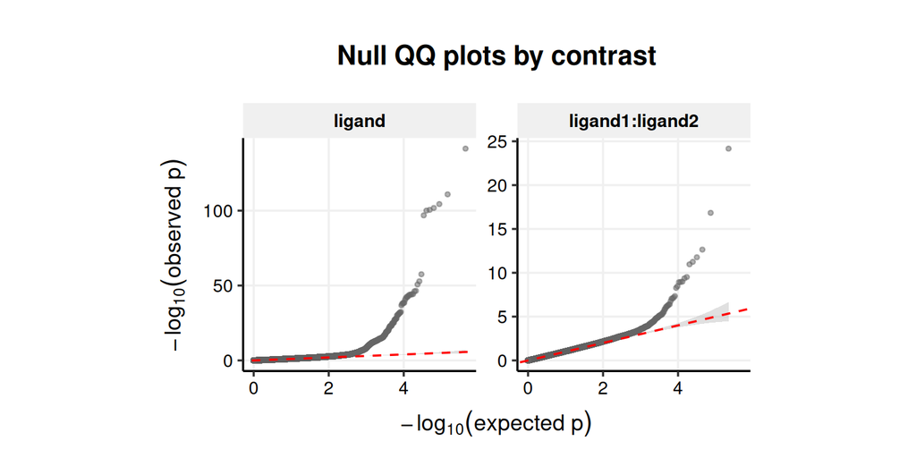

```r
qqData <- nullPvals %>%
  group_by(contrast) %>%
  arrange(pvalue, .by_group = TRUE) %>%
  mutate(
    n = n(),
    rank = row_number(),
    expected = -log10(ppoints(n)),
    observed = -log10(pvalue),
    # Beta distribution CI for each order statistic (on the p-value scale)
    ci_lower = qbeta(0.025, rank, n - rank + 1),
    ci_upper = qbeta(0.975, rank, n - rank + 1),
    # transform to -log10 scale; note bounds swap because -log10 is decreasing
    ci_lower_log = -log10(ci_upper),
    ci_upper_log = -log10(ci_lower)
  ) %>%
  ungroup()

ggplot(qqData, aes(x = expected, y = observed)) +
  geom_ribbon(aes(ymin = ci_lower_log, ymax = ci_upper_log),
              fill = "grey70", alpha = 0.4) +
  geom_point(alpha = 0.5, size = 1, color = "#666666FF") +
  geom_abline(slope = 1, intercept = 0, color = "red", linetype = "dashed") +
  facet_wrap(~contrast, scales = "free_y") +
  labs(x = expression(-log[10](expected~p)), y = expression(-log[10](observed~p)),
       title = "Null QQ plots by contrast") +
  theme(aspect.ratio = 1)
```

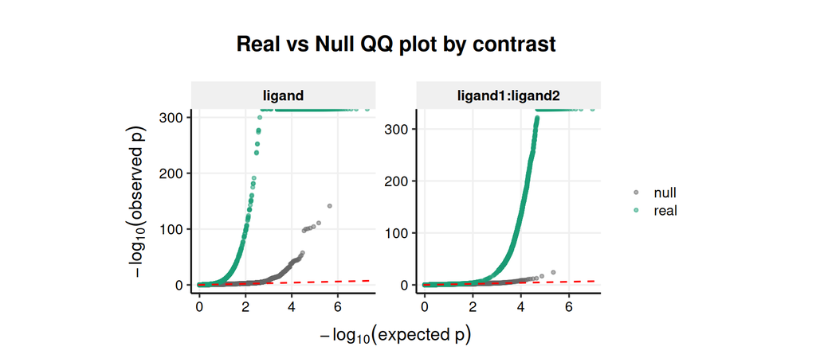

```r
ggsave("../../analysis_outs/plots/interaction_scoring_null/glm_QQ_null.pdf")
set.seed(1)

# keep top points, randomly subsample other points
# purely for plotting efficiency
thin_qq <- function(pvalues, keep_top = 4000, n_bulk_sample = 4000) {
  n <- length(pvalues)
  sorted_p <- sort(pvalues)
  rank <- seq_len(n)
  expected <- -log10((rank - 0.5) / n)
  observed <- -log10(sorted_p)

  keep_idx <- seq_len(min(keep_top, n))
  if (n > keep_top) {
    bulk_idx <- sample(seq(keep_top + 1, n), size = min(n_bulk_sample, n - keep_top))
    keep_idx <- c(keep_idx, bulk_idx)
  }

  tibble(expected = expected[keep_idx], observed = observed[keep_idx])
}

qqOverlay <- allPvals %>%
  group_by(contrast, source) %>%
  group_modify(~ thin_qq(.x$pvalue)) %>%
  ungroup()

ggplot(qqOverlay, aes(x = expected, y = observed, color = source)) +
  geom_point(alpha = 0.5, size = 1) +
  geom_abline(slope = 1, intercept = 0, color = "red", linetype = "dashed") +
  scale_color_manual(values = c("#666666FF", "#1B9E77FF")) +
  facet_wrap(~contrast, scales = "free") +
  labs(x = expression(-log[10](expected~p)), y = expression(-log[10](observed~p)), color = NULL,
       title = "Real vs Null QQ plot by contrast") +
  theme(aspect.ratio = 1)
```

```r
ggsave("../../analysis_outs/plots/interaction_scoring_null/glm_QQ_real_vs_null.pdf")
```

# P-value vs. effect size, real vs. null

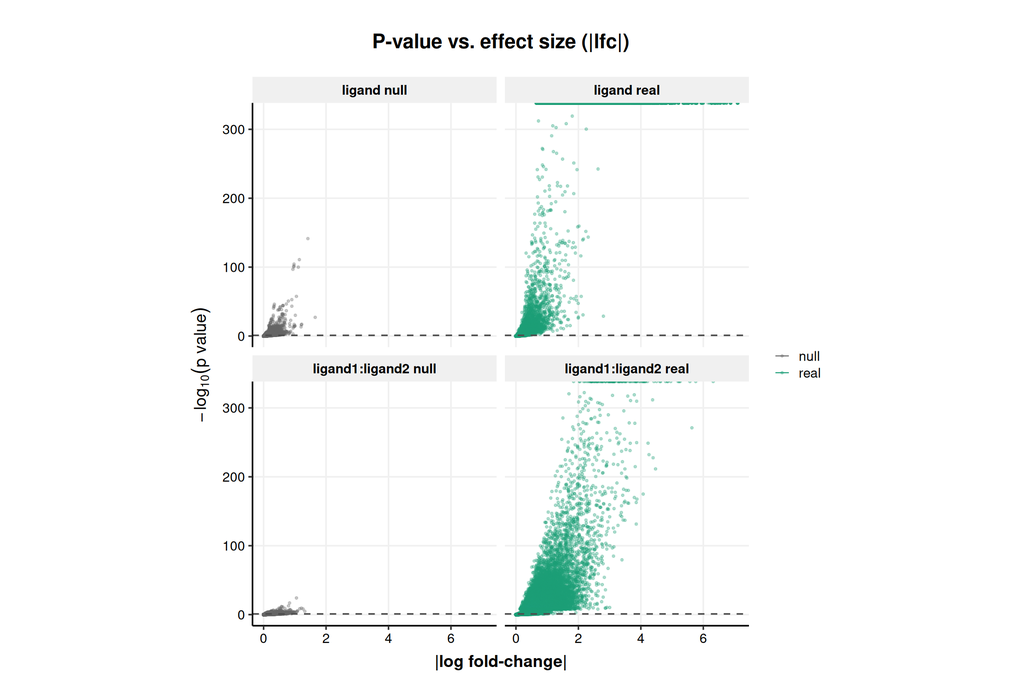

```r
# keep top points, randomly subsample other points
# purely for plotting efficiency
thin_pairs <- function(df, keep_top = 20000, n_bulk_sample = 20000) {
  n <- nrow(df)
  df <- df[order(df$pvalue), ]
  keep_idx <- seq_len(min(keep_top, n))
  if (n > keep_top) {
    bulk_idx <- sample(seq(keep_top + 1, n), size = min(n_bulk_sample, n - keep_top))
    keep_idx <- c(keep_idx, bulk_idx)
  }
  df[keep_idx, ]
}

volcanoData <- allPvals %>%
  mutate(abs_lfc = abs(lfc)) %>%
  mutate(contrast_source = paste(contrast, source)) %>%
  group_by(contrast, source) %>%
  group_modify(~ thin_pairs(.x)) %>%
  ungroup()

ggplot(volcanoData, aes(x = abs_lfc, y = -log10(pvalue), color = source)) +
  geom_point(alpha = 0.3, size = 0.6) +
  geom_density_2d(linewidth = 0.4) +
  geom_hline(yintercept = -log10(0.1), linetype = "dashed", color = "grey30") +
  scale_color_manual(values = c("#666666FF", "#1B9E77FF")) +
  facet_wrap(~contrast_source) +
  labs(x = "|log fold-change|", y = expression(-log[10](p~value)), color = NULL,
       title = "P-value vs. effect size (|lfc|)") +
  theme(aspect.ratio = 1)
```

```r
ggsave("../../analysis_outs/plots/interaction_scoring_null/glm_pval_vs_effect_scatter.pdf")
ggsave("../../analysis_outs/plots/interaction_scoring_null/glm_pval_vs_effect_scatter.png", dpi = 300)
```

# Effect size comparison among significant hits

Comparison of real analysis’s `adj_pval < 0.1` hit effect sizes (`|lfc|`) to the null’s own `adj_pval < 0.1` hits.

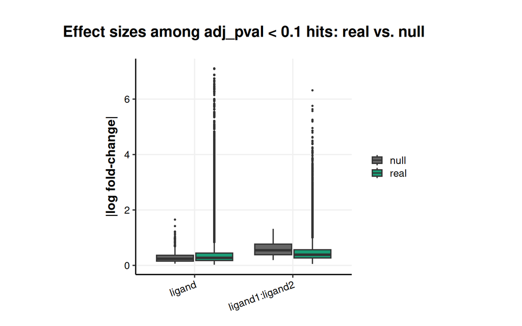

```r
sigEffectSizes <- allPvals %>%
  filter(adj_pval < 0.1) %>%
  mutate(abs_lfc = abs(lfc))

ggplot(sigEffectSizes, aes(x = contrast, y = abs_lfc, fill = source)) +
  geom_boxplot(outlier.size = 0.5, position = position_dodge(width = 0.8)) +
  scale_fill_manual(values = c("#666666FF", "#1B9E77FF")) +
  labs(x = NULL, y = "|log fold-change|", fill = NULL,
       title = "Effect sizes among adj_pval < 0.1 hits: real vs. null") +
  theme(axis.text.x = element_text(angle = 20, hjust = 1),
        aspect.ratio = 1)
```

```r
ggsave("../../analysis_outs/plots/interaction_scoring_null/glm_effect_boxplot_significant_hits.pdf")
```

# P-value Inflation Metrics

## Empirical false-positive rate at the real pipeline’s significance cutoff

```r
nullPvals %>%
  group_by(contrast) %>%
  summarise(
    n_tests = n(),
    n_sig = sum(adj_pval < 0.1, na.rm = TRUE),
    empirical_fpr = n_sig / n_tests
  )
```

```
## # A tibble: 2 × 4
##   contrast        n_tests n_sig empirical_fpr
##   <chr>             <int> <int>         <dbl>
## 1 ligand           222124  1288      0.00580
## 2 ligand1:ligand2  111062    67      0.000603
```

## Hit rate at adj_pval < 0.1: real vs. null

```r
hitRates <- allPvals %>%
  group_by(contrast, source) %>%
  summarise(n_tests = n(), n_sig = sum(adj_pval < 0.1, na.rm = TRUE), hit_rate = n_sig / n_tests, .groups = "drop")

hitRates
```

```
## # A tibble: 4 × 5
##   contrast        source n_tests   n_sig hit_rate
##   <chr>           <chr>    <int>   <int>    <dbl>
## 1 ligand          null    222124    1288 0.00580
## 2 ligand          real   9435942 2629690 0.279
## 3 ligand1:ligand2 null    111062      67 0.000603
## 4 ligand1:ligand2 real   4717971  119275 0.0253
```

```r
hitRates %>%
  select(contrast, source, hit_rate) %>%
  pivot_wider(names_from = source, values_from = hit_rate) %>%
  dplyr::mutate(fold_enrichment_real_over_null = real / null,
         empirical_fdr = null/real)
```

```
## # A tibble: 2 × 5
##   contrast            null   real fold_enrichment_real_over_null empirical_fdr
##   <chr>              <dbl>  <dbl>                          <dbl>         <dbl>
## 1 ligand          0.00580  0.279                            48.1        0.0208
## 2 ligand1:ligand2 0.000603 0.0253                           41.9        0.0239
```

`fold_enrichment_real_over_null` is how many times more often the real analysis calls a gene significant than the null does for the same contrast.